# Untitled

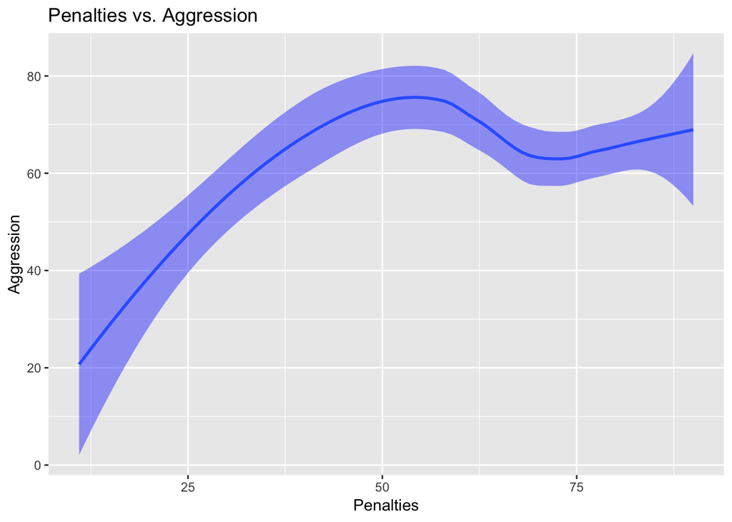

```r
fifadata_tab %>%
  ggplot(mapping = aes(x = Penalties, y = Aggression)) + geom_smooth(fill = "#0000FF" ) +
  labs(title="Penalties vs. Aggression", x = "Penalties", y = "Aggression")
```

*6.10 Violin Graph showing the relationship between work rate and position.* This violin graph shows the spread of the work rate depending on the position of the player. This allows us to discover which position conducts the most amount of work. Based on the graph, it is quite obvious that the goal keeper does very little work, only a rate of 3, and that it is the same for almost every goalkeeper as there is no range for work rate. However, the rest of the positions such as attacker, defender, and midfielder all have spreads ranging between a work rate of 5 to about a work rate of 2 or 3. The attacker position has a higher concentration at work rates 2, 3, 4, and 5 while other positions such as defender and midfielder and even concentration throughout their entire spreads. There is an exception for defender where the violin is wider and work rate 4 compared to the rest of the spread and midfielder gets less wider as it goes from a work rate of 5 down to 2. This graph concludes that goalkeepers do not do much work compared to the rest of the players as they just wait in the goal until the ball comes to them.

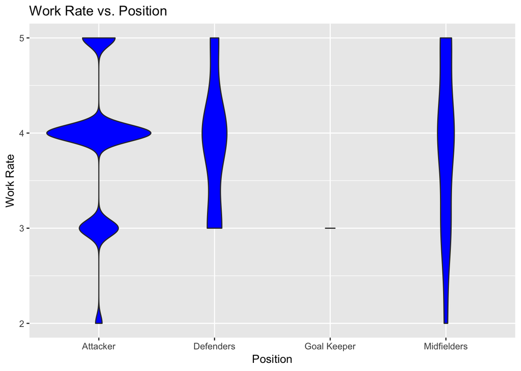

```r
fifadata_tab %>%
  ggplot(mapping = aes(x =`General Position`, y = `Work Rate`)) + geom_violin(fill = "#0000FF" ) +
  labs(title="Work Rate vs. Position", x = "Position", y = "Work Rate")
```

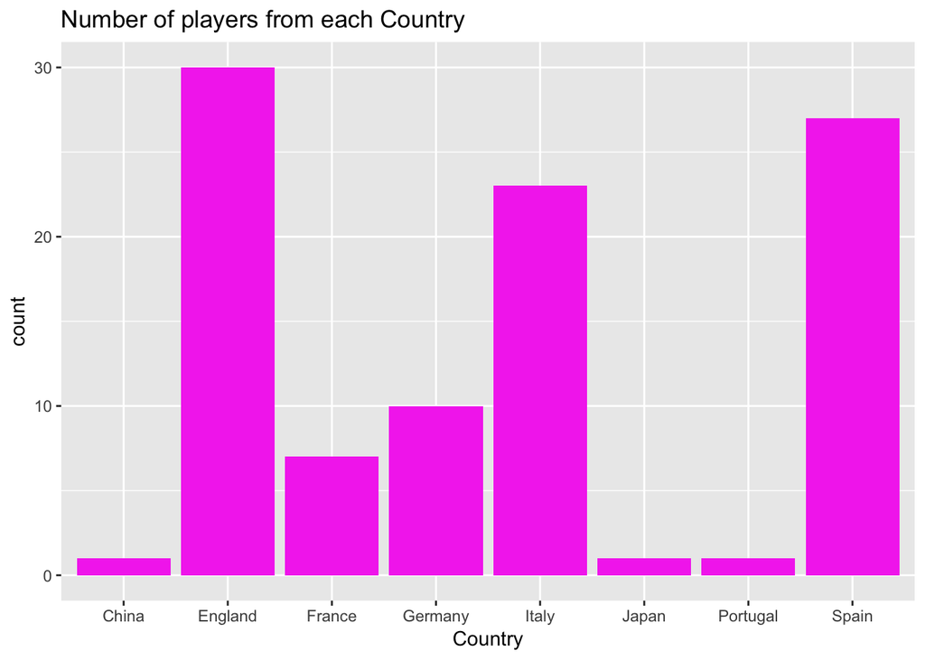

```r
fifadata_tab %>%
  ggplot(mapping = aes(x = Country)) + geom_bar(fill = "#F442EE" ) +
  labs(title="Number of players from each Country", x = "Country")
```